# Uncertainty, the Price of Risk, and the Business Cycle

Southern Economic Association 94th Annual Meeting

Tobias Adrian

International Monetary Fund<sup>1</sup>

Matthew DeHaven

Brown University

Fernando Duarte

Brown University

November 25, 2024

<sup>1</sup>The views expressed here are the authors’ and are not necessarily representative of the views of the International Monetary Fund, its Management, or its Executive Directors.

## What Drives Business Cycles?

- Empirically, a single shock captures majority of business cycle variation in all macro variables
- In models, usually one big shock:
  - TFP, demand, beliefs, confidence, etc.
- Common propagation can look like a single shock

### Why we care

- Type of shock and propagation determine whether fluctuations are inefficient
- Crucial for welfare and policy
- Select models that are consistent with data

## We Construct Three Shocks That Generate Business Cycles

1. Macroeconomic uncertainty shock
   - uncertainty: second moment of output growth
2. Price of risk shock
   - price of risk: equilibrium compensation to hold aggregate risk
3. Business cycle shock
   - statistically constructed to explain as much business cycle variation as possible

Related Literature

## Evidence Points to Financial Shocks or Propagation

- Business cycles tightly linked to financial conditions and macro uncertainty
- Shocks move first and second moments of macro variables at the same time
- Either one big financial shock or common propagation of other shocks through financial system

### Takeaway

- Difficult to reconcile with standard models and shocks
- Suggests models with financial frictions

## VAR Setup

- Structural VAR($p$) with $k$ variables in vector $y_t$
  $$B_0 y_t = B_1 y_{t-1} + . . . + B_p y_{t-p} + w_t$$
  where structural shocks $w_t$ are white noise
- Estimate reduced-form coefficients $A_i$ and residuals $u_t$
  $$y_t = \underbrace{B_0^{-1}B_1}_{A_1} y_{t-1} + \dots + \underbrace{B_0^{-1}B_p}_{A_p} y_{t-p} + \underbrace{B_0^{-1}w_t}_{u_t}$$
- The shock identification problem: $u_t = B_0^{-1} w_t$

## Construct a Macroeconomic Uncertainty Shock

- Estimate VAR
- Let $\sigma_{t+12}$ be the twelve-quarter-ahead forecast error for output growth
- Measure macroeconomic uncertainty by $\mathbb{E}_t\sigma_{t+12}^2$
- Run OLS regression

$$\log \sigma_{t+12}^2 = \alpha y_{t} + \upsilon_t$$

- Fitted value $\widehat{\alpha} y_t$ is a valid instrument for a shock to uncertainty

## The Price of Risk

Absence of arbitrage implies the existence of an SDF (stochastic discount factor)

The SDF can be decomposed as

$$\begin{align}
\text{SDF}_{t+1} = \mathbb{E}_t[\text{SDF}_{t+1}] + \underbrace{\text{Vol}_t[{\text{SDF}_{t+1}}]}_{\lambda_{t}} \epsilon_{t+1}
\end{align}
\qquad(1)$$

where

- $1/\mathbb{E}_t[\text{SDF}_{t+1}]$ is the risk-free rate
- $\lambda_{t}$ is the price of risk
- $\epsilon_{t+1}$ is an innovation

## Estimating the Price of Risk

Assume a representative agent with CRRA utility for simplicity

The FOC of the representative agent is
$$\text{SDF}_{t+1} = \beta \left(\frac{C_{t+1}}{C_t}\right)^{-\gamma}$$
Taking logs and combining with Equation 1, we get

$$\gamma \Delta c_{t,t+1} = \beta - \mathbb{E}_t[\text{sdf}_{t+1}] - \lambda_{t} \varepsilon_{t+1}
\qquad(2)$$

Projecting the $\text{sdf}_{t+1}$ and $\lambda_t$ onto financial returns $R_t$, we can estimate $\lambda_{t}$ through a heteroskedastic regression

## The Price of Risk Shock in the VAR

A heteroskedastic regression can be implemented by a two-step procedure:

1. Estimate the means (the VAR)
2. Estimate the volatility of the residuals by OLS

$$\log \sigma_{t+12}^2 = \delta R_t + \varepsilon_t$$

Then $\widehat{\delta} R_t$ is a shock to the price of risk consistent with the VAR estimation

## VAR Specification

Time period:

- 1962 Q1 to 2022 Q3, with $p=2$ lags.

Macro Variables ($k = 10$):

- In log differences: output, investment, consumption, hours worked, productivity, TFP
- In levels: unemployment, interest rate, inflation, labor share

Financial Variables (summarized by first 4 principal components):

- S&P 500 returns, S&P 500 volatility, term spread, liquidity spread, credit spread, default spread

## Unemployment and Output

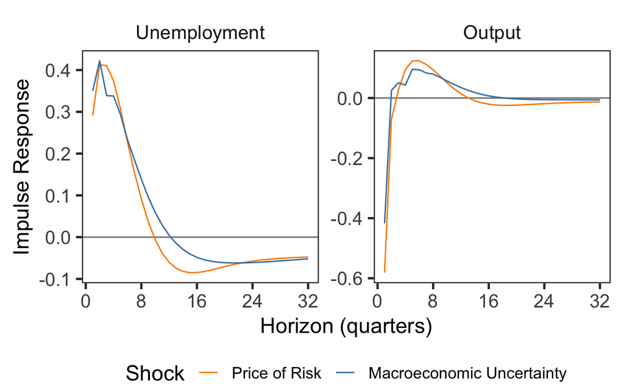

## All Impulse Responses

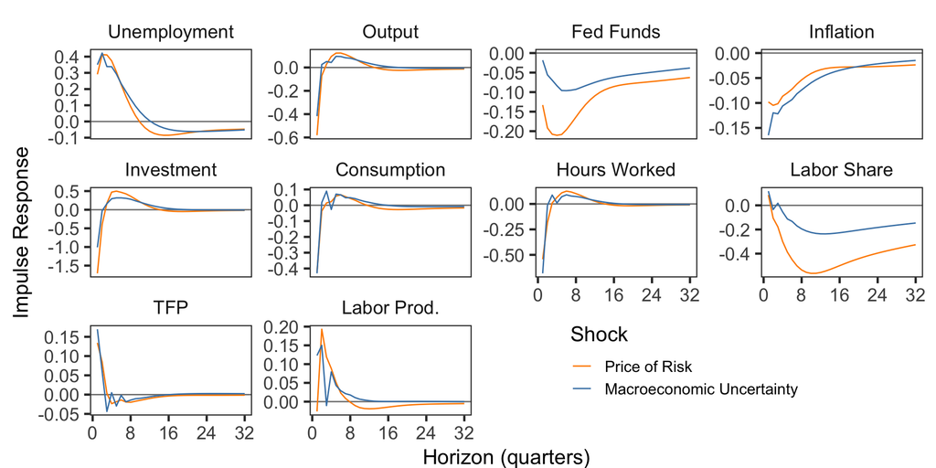

## Historical Shock Contributions

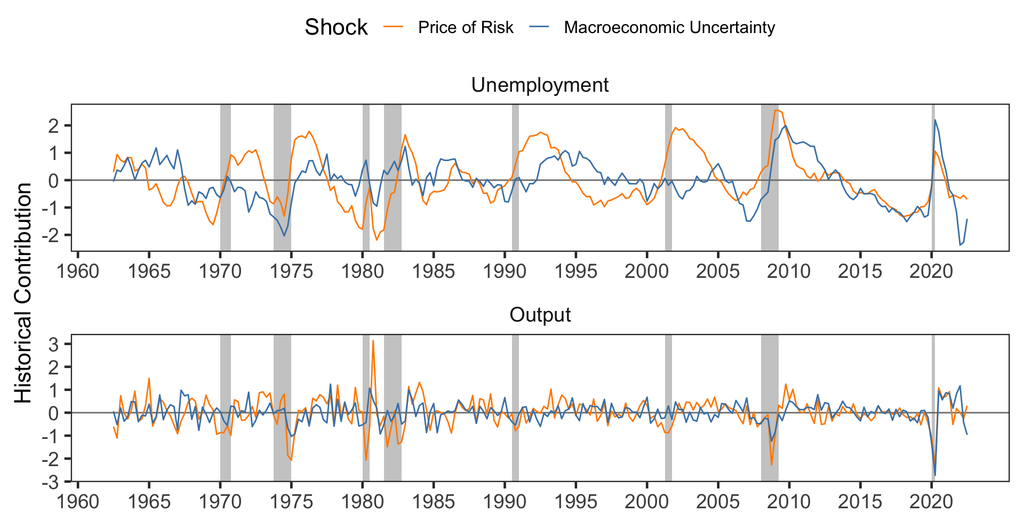

## Business Cycle Shock

Identify the business-cycle shock $w_t^{(\text{MBC})}$ as in Angeletos, Collard, and Dellas (2020).

1. Pick a target variable (e.g. unemployment),
2. Find linear combination of residuals $w_t^{(\text{MBC})} = b^\prime u_t$ that maximizes its contribution to the variance of target variable over business-cycle frequencies.

Using unemployment, output, consumption, investment, or hours worked, produces the same shock

## Comparison to the Business Cycle Shock

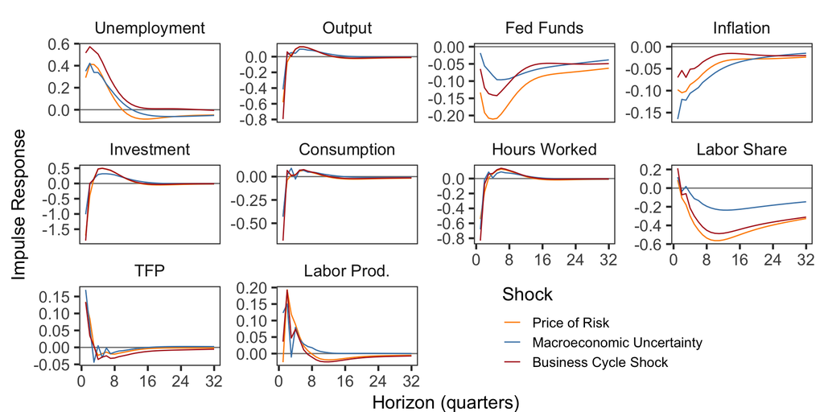

## Comparison to the Business Cycle Shock

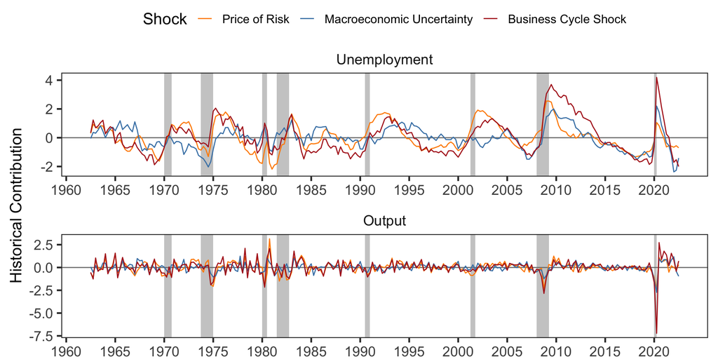

## Conclusion

# Appendix

## References

Adrian, Tobias, Matthew DeHaven, Fernando Duarte, and Tara Iyer. Working Paper. “The Market Price of Risk and Macro-Financial Dynamics.”

Angeletos, George-Marios, Fabrice Collard, and Harris Dellas. 2020. “Business-Cycle Anatomy.” *American Economic Review* 110 (10): 3030–70. https://doi.org/10.1257/aer.20181174.

Brunnermeier, Markus, Darius Palia, Karthik A. Sastry, and Christopher A. Sims. 2021. “Feedbacks: Financial Markets and Economic Activity.” *American Economic Review* 111 (6): 1845–79. https://doi.org/10.1257/aer.20180733.

## Select Related Literature

Angeletos, Collard, and Dellas (2020) — Introduces the “Main Business Cycle Shock” by showing the same shock explains a large portion of the variance of output, unemployment, consumption, investment and hours worked over business cycle frequencies. This same shock does not explain much of the variation in inflation or TFP.

Adrian et al. (Working Paper) — Introduces the “Volatility Financial Conditions Index” (VFCI) as the conditional variance of output growth that is explained by financial factors. The VFCI is the first FCI grounded in theory and does a better job explaining credit spreads than other FCIs.

Brunnermeier et al. (2021) — Identifies a structural VAR with heteroskedastic regimes in order to look at credit expansions and financial stress shocks.

What Do We Do?